# Sviluppo e validazione di una scala di misura per valutare la credenza nei neuromiti tra gli insegnanti

Francesco Carabba

francesco.carabba@unibz.it

Free University of Bolzano

Supervisor: Prof. Dr. Demis Basso

demis.basso@unibz.it

Free University of Bolzano

Co-Supervisor: Ottavia M. Epifania, Ph.D.

ottavia.epifania@unitn.it

University of Trento

# Introduzione

## I neuromiti

Interpretazioni errate o distorte di ricerche scientifiche sul cervello, spesso usate per supportare affermazioni in ambito educativo o in altri contesti (Economic Co-operation & Development, 2002).

**Warning**

“L’emisfero sinistro è quello logico mentre l’emisfero destro è quello creativo”

**Warning**

“L’apprendimento dipende esclusivamente dalla crescita sinaptica durante la prima infanzia”

## Misurare i neuromiti negli insegnanti

Gli insegnanti svolgono un ruolo fondamentale nella società e spesso attingono alla loro comprensione del cervello e della mente nel loro lavoro quotidiano.

**Tip**

**Credere ai neuromiti può influire sulla qualità dell’insegnamento.**

## Sviluppare una nuova scala

- Non esiste una scala di misura che abbia ricevuto un’appropriata validazione psicometrica (né in Italia né in altre nazioni).
- Il questionario più utilizzato finora (Dekker et al., 2012) presenta alcuni limiti al di là della mancata validazione:
  - Valuta le convinzioni dei partecipanti utilizzando un formato di risposta sì/no.
  - Valuta solo la conoscenza dichiarativa e non quella procedurale.

# Obiettivo

## Obiettivo

Sviluppare e validare due nuove scale di misura per valutare la credenza nei neuromiti tra gli insegnanti italiani: una a livello **procedurale** e una a livello **dichiarativo**.

# Studio preliminare

## Studio preliminare

- Sviluppo e validazione di una scala di misura per valutare la conoscenza procedurale dei processi di **memoria** e **apprendimento**.
- 60 item a scelta multipla (3 opzioni errate e 1 corretta) a partire dai manuali sulla memoria e sull’apprendimento di Baddeley et al. (2021) e di Cornoldi et al. (2018).
- Campione di 600 insegnanti italiani.
- EFA e CFA per indagare la validità di costrutto.

## Esempio scala preliminare

*La classe deve apprendere un capitolo di un manuale per il prossimo compito in classe. Dopo aver letto il capitolo una volta cosa conviene fare?*

1. *Cercare di richiamare alla mente il contenuto del capitolo.*
2. *Tornare indietro e ristudiare l’intero capitolo.*
3. *Tornare indietro e ristudiare alcune parti del capitolo.*
4. *Sintetizzare il contenuto del capitolo.*

# Studio principale

## Scala procedurale

- 25 item vengono selezionati dalla scala precedentemente validata.
- Al posto di un distrattore, un **neuromito** viene inserito (5 item per ciascuno dei 5 neuromiti).
- Questi item vengono combinati con i rimanenti item non modificati.

## Esempio scala procedurale

*La classe deve apprendere un capitolo di un manuale per il prossimo compito in classe. Dopo aver letto il capitolo una volta cosa conviene fare?*

1. *Cercare di richiamare alla mente il contenuto del capitolo.*
2. *Tornare indietro e ristudiare l’intero capitolo.*
3. *Ascoltare una registrazione del capitolo per chi ha uno stile di apprendimento uditivo.*
4. *Sintetizzare il contenuto del capitolo.*

## Scala dichiarativa

- Le 25 opzioni di risposta della scala procedurale contenenti un neuromito vengono trasformate in item.
- 5 affermazioni vere sui processi di memoria e apprendimento vengono aggiunte.
- Livello di accordo su una scala Likert a 5 punti.

## Esempio scala dichiarativa

*Ascoltare delle informazioni è una tecnica di apprendimento maggiormente efficace per chi ha uno stile di apprendimento uditivo.*

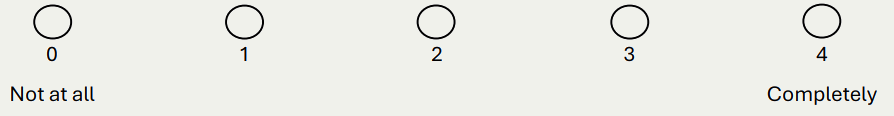

## Validazione delle due scale

- Campione di 400 insegnanti italiani.

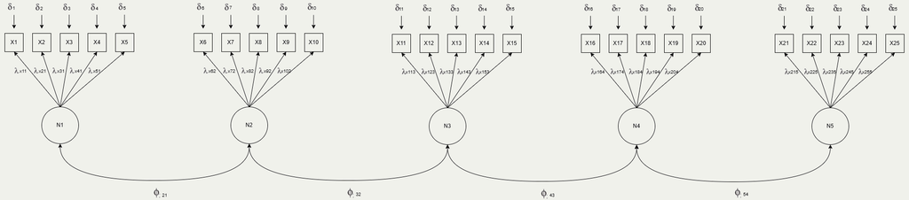

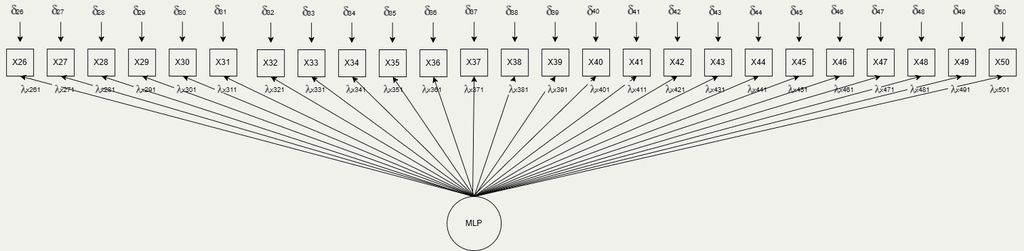

- Associazione tra conoscenza dei processi di memoria e apprendimento e adesione ai neuromiti → regressione multinomiale (livello procedurale) e SEM (livello dichiarativo)

# Bibliografia

## Bibliografia

Baddeley, A., Eysenck, M. W., & Anderson, M. C. (2021). *La memoria*. Società editrice il Mulino, Spa.

Cornoldi, C., Meneghetti, C., Moè, A., & Zamperlin, C. (2018). *Processi cognitivi, motivazione e apprendimento*. Il Mulino.

Dekker, S., Lee, N. C., Howard-Jones, P., & Jolles, J. (2012). Neuromyths in education: Prevalence and predictors of misconceptions among teachers. *Frontiers in Psychology*, *3*, 33784.

Economic Co-operation, O. for, & Development. (2002). *Understanding the brain: Towards a new learning science*. OECD Publishing.